# Survival Analysis with nlmixr2

Justin Wilkins and the nlmixr2 Development Team

2026-05-03

# Introduction

Survival or time-to-event (TTE) analysis models *when* something happens, not just whether it happens. The endpoint might be time to tumour progression, time to an adverse event, or time to treatment discontinuation, for instance. In this post we’ll illustrate how to fit parametric TTE models in `nlmixr2` using its custom log-likelihood interface.

For the purposes of this post, we’re going to simulate a two-arm randomised trial from a known Gompertz model, then recover the parameters with `nlmixr2`. This is cheating, obviously, but since we’ll know what the truth is, we’ll be able to directly assess how well the model does in recovering the parameters.

## Simulated Dataset

We are going to generate 300 patients (150 per arm) from a Gompertz proportional-hazards model with increasing hazard ($\gamma > 0$) and a 50% drug-induced hazard reduction (HR = 0.5).

$$h(t \mid \text{test\_trt}) =
\underbrace{\alpha \, e^{\gamma t}}_{\text{baseline Gompertz}}
\cdot \exp(\beta \cdot \text{test\_trt})$$

| Parameter | True value | Interpretation |
| --- | --- | --- |
| $\alpha$ | 0.002 /day | Initial hazard (placebo) |
| $\gamma$ | 0.005 /day | Hazard growth rate; $\gamma>0$ → increasing risk |
| $\beta$ | $\log(0.5) \approx -0.693$ | Log hazard ratio, drug vs. placebo |

We’ll use a universal cutoff at 365 days. We can use the closed-form Gompertz inverse-CDF for simulation:

```r
n_arm       <- 150
true_alpha  <- 0.002
true_gamma  <- 0.005
true_log_hr <- log(0.5)
maxt        <- 365

n_total  <- 2L * n_arm
test_trt <- rep(0L:1L, each = n_arm)   # 0 = placebo, 1 = drug

u       <- runif(n_total)
hr_vec  <- exp(true_log_hr * test_trt)
# Gompertz inverse-CDF: t = log(1 + gamma*(-log U)/(alpha*hr)) / gamma
t_event <- log(1 + true_gamma * (-log(u)) / (true_alpha * hr_vec)) / true_gamma

tte_sim <- data.frame(
  id       = seq_len(n_total),
  time     = pmin(t_event, maxt),
  event    = as.integer(t_event <= maxt),
  test_trt = test_trt,
  dv       = pmin(t_event, maxt),
  evid     = 0L
)

cat(sprintf(
  "%d patients | Placebo: %d events (%.0f%%) | Drug: %d events (%.0f%%)\n",
  nrow(tte_sim),
  sum(tte_sim$event[tte_sim$test_trt == 0]),
  100 * mean(tte_sim$event[tte_sim$test_trt == 0]),
  sum(tte_sim$event[tte_sim$test_trt == 1]),
  100 * mean(tte_sim$event[tte_sim$test_trt == 1])
))
```

```
## 300 patients | Placebo: 138 events (92%) | Drug: 99 events (66%)
```

The increasing hazard means events become more frequent late in follow-up. The drug-treatment arm retains more survivors throughout.

## Exploratory Analysis

Plotting the data is something everyone should always do first.

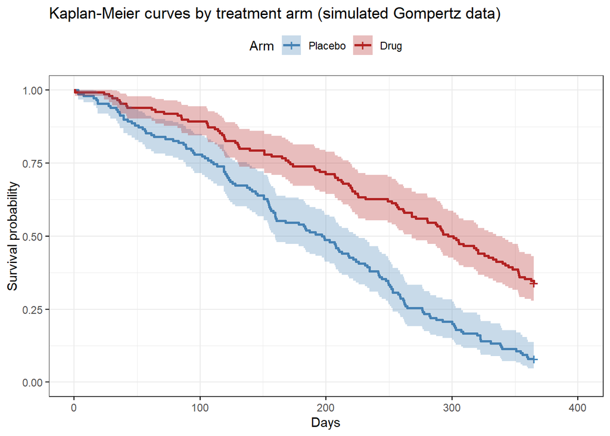

```r
tte_sim$trt_label <- factor(tte_sim$test_trt, levels = 0:1,
                             labels = c("Placebo", "Drug"))
km_fit <- survfit(Surv(time, event) ~ trt_label, data = tte_sim)

ggsurvplot(
  km_fit, data = tte_sim,
  palette      = c("steelblue", "firebrick"),
  legend.labs  = c("Placebo", "Drug"),
  legend.title = "Arm",
  xlab = "Days", ylab = "Survival probability",
  title   = "Kaplan-Meier curves by treatment arm (simulated Gompertz data)",
  conf.int = TRUE, ggtheme = theme_bw()
)
```

The two arms separate clearly (by design, of course). Note the acceleration in event rate late in follow-up — a signature of the increasing ($\gamma > 0$) Gompertz hazard that a typical exponential model cannot capture accurately.

### Hazard shape exploration

Before choosing a parametric form, we overlay several distributions against a kernel density hazard estimate and compare AICs. The `plot_hazard` helper below fits six standard distributions and two cubic-spline models via `flexsurv`.

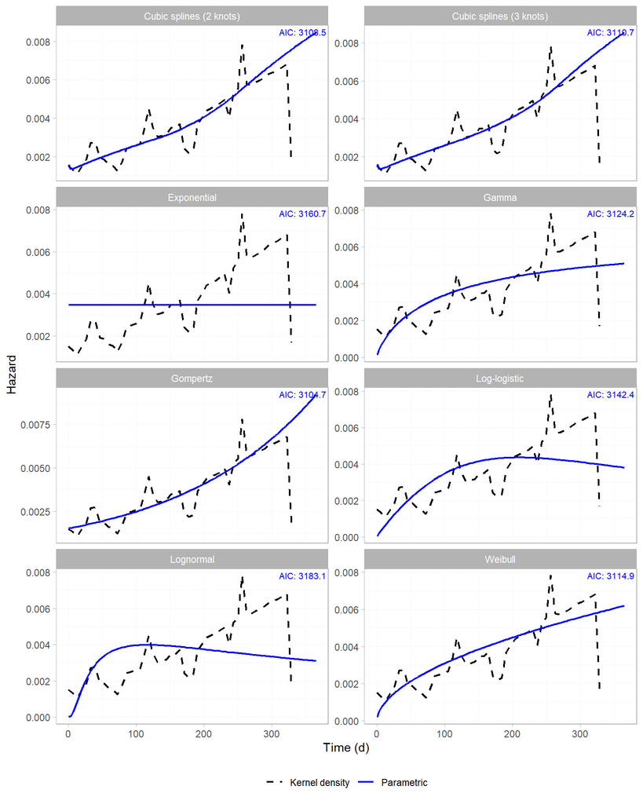

```r
plot_hazard(dat = tte_sim, stime = "time", evt = "event")
```

The Gompertz panel tracks the kernel density closely, as expected from a correctly-specified model. The exponential panel (constant hazard) clearly doesn’t work here, although some of the other alternatives do reasonably well.

## Model 1 — Exponential (Constant Hazard)

The exponential model assumes constant hazard over time. We know this is the wrong model, but it’s a handy baseline for comparison. The drug effect is represented by $trt_i$, which is 0 (placebo) or 1 (treatment):

$$h_i(t) = h_0 \exp(\beta \cdot
trt_i)$$

The log-likelihood contribution per patient is:

$$\ell_i = \delta_i \log h_i - H_i(t_i) =
\delta_i \log h_i - h_i \, t_i$$

where $\delta_i = 1$ for an event and $0$ for a censored observation. In `nlmixr2` we can write this via the `ll()` interface:

```r
exp_model <- function() {
  ini({
    log_h0      <- log(0.004)
    test_log_hr <- -0.1
  })
  model({
    log_h  <- log_h0 + test_log_hr * test_trt
    h      <- exp(log_h)
    H      <- h * time
    tte_ll <- event * log_h - H
    ll(tte) ~ tte_ll
  })
}

fit_exp <- nlmixr(exp_model, tte_sim, est = "bobyqa",
                  control = bobyqaControl(print = 0))
```

```
## [====|====|====|====|====|====|====|====|====|====] 0:00:00
```

```
## [====|====|====|====|====|====|====|====|====|====] 0:00:00
```

```
## |-----+---------------+-----------+-----------|
```

```
## [====|====|====|====|====|====|====|====|====|====] 0:00:00
```

```
## [====|====|====|====|====|====|====|====|====|====
## =|====|====|====|====|====|====|====] 0:00:00
```

```
## [====|====|====|====|====|====|====|====|====|====] 0:00:00
```

```r
fit_exp$parFixedDf
```

```
##               Estimate        SE      %RSE Back-transformed  CI Lower
## log_h0      -5.3474952 0.1702513  3.183758       -5.3474952 -5.681182
## test_log_hr -0.6371551 0.2634190 41.342991       -0.6371551 -1.153447
##               CI Upper BSV(SD) Shrink(SD)%
## log_h0      -5.0138088      NA          NA
## test_log_hr -0.1208634      NA          NA
```

So far so good.

## Model 2 — Gompertz (Increasing Hazard)

The Gompertz model adds a shape parameter $\gamma$ governing the rate of hazard change. With $\gamma > 0$ the hazard increases exponentially, as we saw in the plot comparing hazard functions above.

$$h_i(t) = \alpha \, e^{\gamma t}
\exp(\beta \cdot trt_i)
\qquad
H_i(t) = \frac{\alpha}{\gamma}\bigl(e^{\gamma t}-1\bigr)
\exp(\beta \cdot trt_i)$$

Important: both $\alpha$ and $\gamma$ are log-transformed in the `ini()` block so that all three estimated parameters live on a similar numerical scale. This avoids potential conditioning problems that arise when the `bobyqa` estimation method has to simultaneously adjust parameters of magnitude $\sim\!10^{-3}$ and $\sim\!10^{0}$, which can lead to the model getting stuck in local minima.

In the model below, we’ve added a drug effect using `test_log_hr`.

```r
gompertz_model <- function() {
  ini({
    log_alpha   <- log(0.003)
    log_gamma   <- log(0.003)   # gamma = exp(log_gamma) > 0 enforced
    test_log_hr <- -0.5         # informed by KM: ~40-50% separation visible
  })
  model({
    alpha  <- exp(log_alpha)
    gamma  <- exp(log_gamma)
    h      <- alpha * exp(gamma * time) * exp(test_log_hr * test_trt)
    H      <- (alpha / gamma) * (exp(gamma * time) - 1) * exp(test_log_hr * test_trt)
    tte_ll <- event * log(h) - H
    ll(tte) ~ tte_ll
  })
}

fit_gompertz <- nlmixr(gompertz_model, tte_sim, est = "bobyqa",
                       control = bobyqaControl(print = 0))
```

```
## [====|====|====|====|====|====|====|====|====|====] 0:00:00
```

```
## [====|====|====|====|====|====|====|====|====|====] 0:00:00
```

```
## |-----+---------------+-----------+-----------+-----------|
```

```
## [====|====|====|====|====|====|====|====|====|====] 0:00:00
```

```
## [====|====|====|====|====|====|====|====|====|====
## ====|====|====|====|====|====|====] 0:00:00
```

```
## [====|====|====|====|====|====|====|====|====|====] 0:00:00
```

```r
fit_gompertz$parFixedDf
```

```
##               Estimate        SE      %RSE Back-transformed     CI Lower
## log_alpha   -6.1983074 0.2885735  4.655682      0.002032869  0.001154716
## log_gamma   -5.1723567 0.2337411  4.519044      0.005671188  0.003586850
## test_log_hr -0.8280953 0.2679623 32.358876     -0.828095297 -1.353291809
##                 CI Upper BSV(SD) Shrink(SD)%
## log_alpha    0.003578850      NA          NA
## log_gamma    0.008966745      NA          NA
## test_log_hr -0.302898786      NA          NA
```

```r
theta_g <- fit_gompertz$theta
kable(
  data.frame(
    Parameter   = c("alpha (/day)", "gamma (/day)", "HR (drug vs. placebo)"),
    True        = c(true_alpha, true_gamma, exp(true_log_hr)),
    Estimated   = round(c(exp(theta_g["log_alpha"]),
                          exp(theta_g["log_gamma"]),
                          exp(theta_g["test_log_hr"])), 4),
    Interpretation = c(
      "Initial hazard at t = 0, placebo arm",
      "Hazard growth rate; >0 confirms increasing risk",
      "Instantaneous hazard ratio, drug vs. placebo"
    )
  ),
  digits = 4,
  caption = "Gompertz parameter recovery: true vs. estimated values"
)
```

Gompertz parameter recovery: true vs. estimated values

|  | Parameter | True | Estimated | Interpretation |
| --- | --- | --- | --- | --- |
| log_alpha | alpha (/day) | 0.002 | 0.0020 | Initial hazard at t = 0, placebo arm |
| log_gamma | gamma (/day) | 0.005 | 0.0057 | Hazard growth rate; >0 confirms increasing risk |
| test_log_hr | HR (drug vs. placebo) | 0.500 | 0.4369 | Instantaneous hazard ratio, drug vs. placebo |

The model recovers $\alpha$ and $\gamma$ closely. The estimated HR is in the right direction and magnitude; there’s a bit of deviation from the true 0.5, reflecting the limitations of this kind of data.

As we alluded to above, starting estimates matter. `bobyqa` is a trust-region optimizer with no built-in multi-start, so it can get stuck if the initial values are far from the truth. If the parameter estimates look suspicious, try perturbing the `ini()` values, or increase `npt` in `bobyqaControl()` — e.g. `npt = 7` (Powell’s recommended $2n+1$ for $n = 3$ parameters) gives the quadratic approximation more interpolation points and a better chance of finding the global optimum. For difficult problems, running from a small grid of starting values and keeping the fit with the lowest objective function value is probably the most robust approach.

## Model Comparison

```r
aic_table <- AIC(fit_exp, fit_gompertz) %>%
  as.data.frame() %>%
  tibble::rownames_to_column("Model") %>%
  mutate(
    Model = c("Exponential", "Gompertz"),
    m2LL  = round(c(-2 * logLik(fit_exp), -2 * logLik(fit_gompertz)), 2)
  )

kable(aic_table, digits = 2,
      caption = "AIC and -2 log-likelihood: exponential vs. Gompertz")
```

AIC and -2 log-likelihood: exponential vs. Gompertz

| Model | df | AIC | m2LL |
| --- | --- | --- | --- |
| Exponential | 2 | 3138.87 | 3134.87 |
| Gompertz | 3 | 3067.84 | 3061.84 |

The Gompertz fit is unambiguously the best. Since this is a simulated example, it would be weird if it wasn’t!

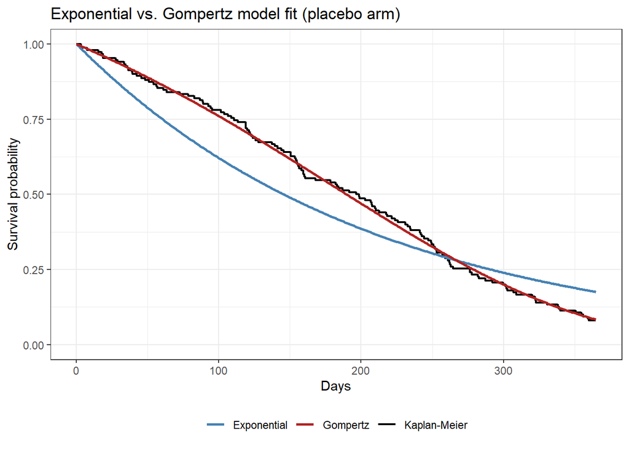

```r
theta_e <- fit_exp$theta
h0_exp  <- exp(theta_e["log_h0"])
alpha_g <- exp(theta_g["log_alpha"])
gamma_g <- exp(theta_g["log_gamma"])

t_grid <- seq(0, maxt, length.out = 400)

exp_surv      <- function(t)     exp(-h0_exp * t)
gompertz_surv <- function(t, hr) exp(-(alpha_g / gamma_g) * (exp(gamma_g * t) - 1) * hr)

model_pred_df <- bind_rows(
  data.frame(time = t_grid, survival = exp_surv(t_grid),         model = "Exponential"),
  data.frame(time = t_grid, survival = gompertz_surv(t_grid, 1), model = "Gompertz")
)

km_plac    <- survfit(Surv(time, event) ~ 1, data = filter(tte_sim, test_trt == 0))
km_plac_df <- data.frame(time     = c(0, km_plac$time),
                          survival = c(1, km_plac$surv),
                          model    = "Kaplan-Meier")

ggplot() +
  geom_step(data = km_plac_df,    aes(time, survival, color = model), linewidth = 0.8) +
  geom_line(data = model_pred_df, aes(time, survival, color = model), linewidth = 1) +
  scale_color_manual(values = c("Kaplan-Meier" = "black",
                                "Exponential"  = "steelblue",
                                "Gompertz"     = "firebrick")) +
  labs(x = "Days", y = "Survival probability",
       title = "Exponential vs. Gompertz model fit (placebo arm)", color = NULL) +
  coord_cartesian(ylim = c(0, 1)) +
  theme_bw() + theme(legend.position = "bottom")
```

## Predicted Survival Curves vs. Observed KM

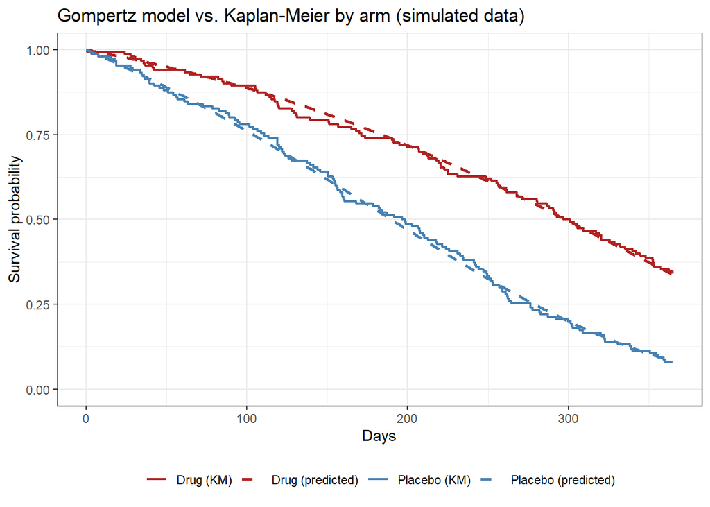

```r
hr_drug <- exp(theta_g["test_log_hr"])

pred_df <- bind_rows(
  data.frame(time = t_grid, survival = gompertz_surv(t_grid, 1),       arm = "Placebo (predicted)"),
  data.frame(time = t_grid, survival = gompertz_surv(t_grid, hr_drug), arm = "Drug (predicted)")
)

km_arms <- lapply(c(0, 1), function(d) {
  label <- if (d == 0) "Placebo" else "Drug"
  fit   <- survfit(Surv(time, event) ~ 1, data = filter(tte_sim, test_trt == d))
  data.frame(time = c(0, fit$time), survival = c(1, fit$surv),
             arm = paste0(label, " (KM)"))
})
km_df2 <- bind_rows(km_arms)

cols <- c("Placebo (KM)"      = "steelblue", "Placebo (predicted)" = "steelblue",
          "Drug (KM)"         = "firebrick", "Drug (predicted)"    = "firebrick")

ggplot() +
  geom_step(data = km_df2,  aes(time, survival, color = arm), linewidth = 0.8) +
  geom_line(data = pred_df, aes(time, survival, color = arm),
            linewidth = 1, linetype = "dashed") +
  scale_color_manual(values = cols) +
  labs(x = "Days", y = "Survival probability",
       title = "Gompertz model vs. Kaplan-Meier by arm (simulated data)",
       color = NULL) +
  coord_cartesian(ylim = c(0, 1)) +
  theme_bw() + theme(legend.position = "bottom")
```

Dashed lines are Gompertz predictions; solid steps are the Kaplan-Meier estimates. The predicted curves track both arms closely across the full follow-up period.

## A TTE VPC

A visual predictive check (VPC) for a TTE model simulates many replicate trials from the fitted model — applying the same censoring rule — and asks whether the observed Kaplan-Meier curve is plausible within the resulting reference band. For TTE endpoints `vpc::vpc_tte()` handles the per-replicate Kaplan-Meier construction automatically; we just need to supply the observed and simulated data frames in the expected format (`id`, `t`, `dv`).

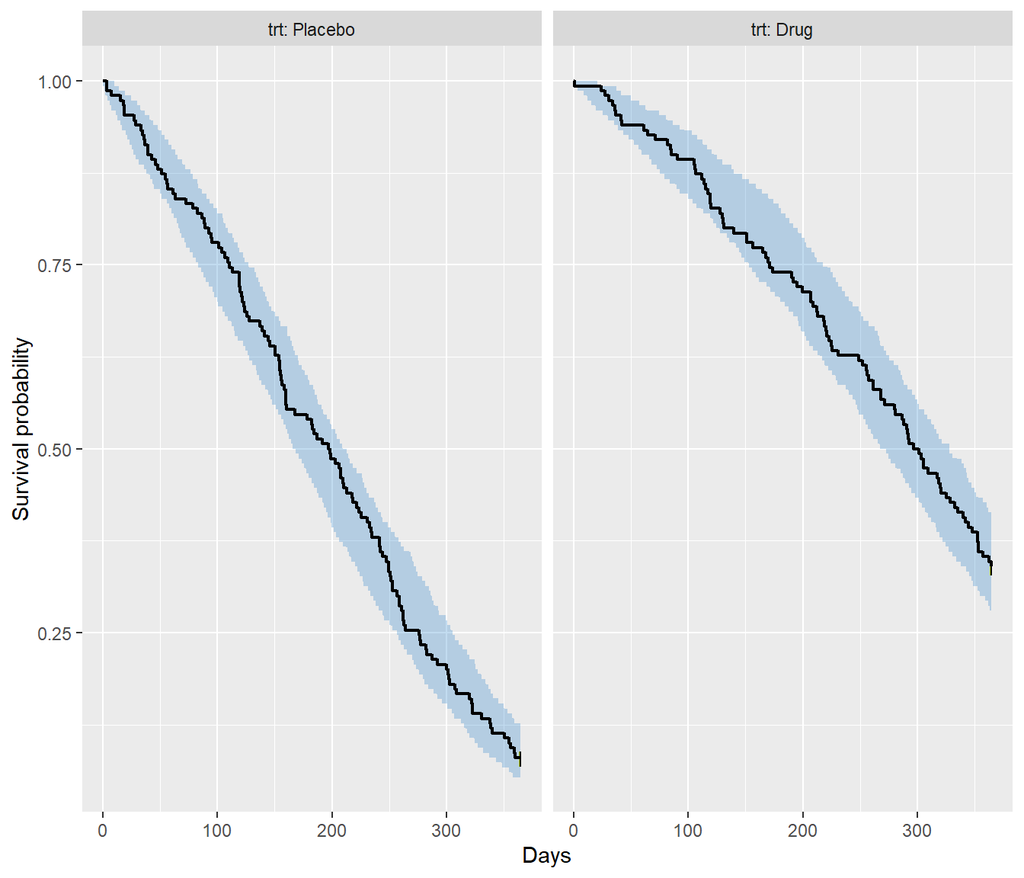

```r
n_vpc_sim <- 200
set.seed(8675)

vpc_obs <- tte_sim %>%
  transmute(id = id, t = time, dv = event, trt = trt_label)

vpc_sim <- bind_rows(
  lapply(seq_len(n_vpc_sim), function(s) {
    u      <- runif(nrow(tte_sim))
    hr_vec <- exp(theta_g["test_log_hr"] * tte_sim$test_trt)
    t_evt  <- log(1 + gamma_g * (-log(u)) / (alpha_g * hr_vec)) / gamma_g
    data.frame(
      sim = s,
      id  = tte_sim$id,
      t   = pmin(t_evt, maxt),
      dv  = as.integer(t_evt <= maxt),
      trt = tte_sim$trt_label
    )
  })
)

suppressMessages(suppressWarnings(
  vpc::vpc_tte(
    obs      = vpc_obs,
    sim      = vpc_sim,
    obs_cols = list(id = "id", idv = "t", dv = "dv"),
    sim_cols = list(id = "id", idv = "t", dv = "dv", sim = "sim"),
    stratify = "trt",
    plot     = FALSE,
    as_percentage = FALSE,
    xlab  = "Days",
    ylab  = "Survival probability",
    title = "Gompertz TTE VPC by treatment arm"
  )
))
```

## Wrapping it up

So that’s how to fit parametric TTE models in `nlmixr2` using the custom log-likelihood interface (`ll(tte) ~ tte_ll`). To recap, the workflow is:

1. Wrangle data into `id / time / dv / evid / event` format.
2. Define hazard $h$ and cumulative hazard $H$ in the `model()` block.
3. Fit with `nlmixr()` using `bobyqa` (no symbolic gradients required).
4. Log-transform shape parameters with potentially small values to keep all parameters on a comparable scale for the optimizer.

The Gompertz model recovered the known simulation parameters closely in this synthetic example. We can extend the same structure naturally to exposure-driven TTE models and repeated time-to-event endpoints. Watch this space!